# Solution to Exercise 7.1

### 02409 Multivariate Statistics

`Week C`

**Principal Component Analysis on Olympic data - Heptathlon**

The data set consists of the results for the 25 athletes that finished the 1988 Olympic women’s heptathlon competition in Seoul.

The results may be found in http://todor66.com/olim/1988/Athletics/Women_Heptathlon.html

The following variables are available:

1. points - the number of points obtained
2. hurdles - results 100m hurdless
3. highjump - results high jump
4. shot - results shot
5. run200m - results 200m race
6. longjump - results long jump
7. javelin - results javelin
8. run800m - results 800m race

```r
Heptathlon = data.frame("Name" = c("Joyner_Kersee,(USA)","John,(GDR)","Behmer,(GDR)","Choubenkova,(URS)","Sablovskaite,(URS)","Schulz,(GDR)","Fleming,(AUS)","Greiner,(USA)","Lajbnerova,(CZE)","Bouraga,(URS)","Wijnsma,(HOL)","Dimitrova,(BUL)","Scheider,(SWI)","Braun,(FRG)","Ruotsalainen,(FIN)","Yuping,(CHN)","Hagger,(GB)","Brown,(USA)","Mulliner,(GB)","Hautenauve,(BEL)","Kytola,(FIN)","Geremias,(BRA)","Hui-Ing,(TAI)","Jeong-Mi,(KOR)","Launa,(PNG)"),
                      "Points"= c(7291,6897,6858,6540,6456,6411,6351,6297,6252,6232,6205,6171,6157,6109,6101,6087,5975,5972,5746,5734,5686,5508,5290,5289,4566),
                      "Hurdles" = c(12.69,12.85,13.20,13.51,13.61,13.75,13.38,13.55,13.63,13.25,13.75,13.24,13.85,13.71,13.79,13.93,13.47,14.07,14.39,14.04,14.31,14.23,14.85,14.53,16.42),
                      "High Jump"=c(1.86,1.80,1.83,1.74,1.80,1.83,1.80,1.80,1.83,1.77,1.86,1.80,1.86,1.83,1.80,1.86,1.80,1.83,1.71,1.77,1.77,1.71,1.68,1.71,1.50),
                       "Shot" = c(15.80,16.23,14.20,14.76,15.23,13.50,12.88,14.13,14.28,12.62,13.01,12.02,11.58,13.16,12.32,14.21,12.75,12.69,12.68,11.81,11.66,12.95,10.00,10.83,11.78),
                       "Run200" = c(22.56,23.65,23.10,23.93,23.92,24.65,23.59,24.48,24.86,23.59,25.03,23.59,24.87,24.78,24.61,25.00,25.47,24.83,24.92,25.61,25.69,25.50,25.23,26.61,26.16),
                       "Longjump" = c(7.27,6.71,6.68,6.32,6.25,6.33,6.37,6.47,6.11,6.28,6.34,6.19,6.05,6.12,6.08,6.40,6.34,6.13,6.10,5.99,5.75,5.50,5.47,5.50,4.88),
                       "Javelin" = c(45.66,42.56,44.54,47.46,42.78,42.82,40.28,38.00,43.30,39.06,37.86,37.62,47.50,44.58,45.44,38.60,35.78,44.34,37.76,35.68,39.48,39.64,39.14,39.26,46.38),
                       "Run800" = c(128.51,126.14,124.20,127.90,132.24,125.79,132.54,133.65,136.05,134.74,131.49,135.73,134.93,142.82,137.06,146.67,138.48,146.43,138.02,133.90,133.35,144.02,137.30,139.17,163.43))
```

**1. Make a scatter plot of the data and calculate the correlation coefficients. What relationship do you see between the plots and the correlation coefficients?**

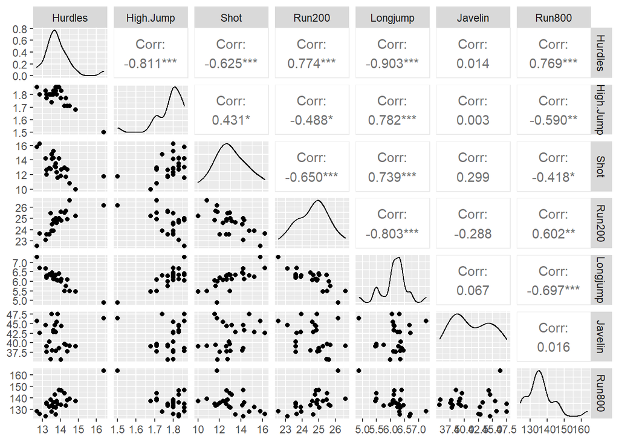

```r
competitors = Heptathlon[,1]
H <- Heptathlon[,c(-1,-2)]
ggpairs(H)
```

For a variable like e.g. javelin we see relatively small correlations with the other variables. The way this is reflected in the scatter plots is that the ellipses have axes almost parallel to the coordinate axes. If we instead consider run200m and longjump, we see that those variables are strongly correlated with a negative correlation coefficient. This corresponds to that an athlete that is running fast - i.e. have a very low value of run200m - also will be able to jump far.

**2. Run a principal component analysis (PCA) on the variables, excluding the number of points obtained, and make the score plots.**

**How many principal components should you use?**

**Which variables are explained by each principal component? What is the relation to the correlation matrix?**

**Note: For consistency of description of the PC loadings and scores for PC1 are multiplied by -1 to have the same explanations.**

```r
# Principal Component Analysis on the correlation matrix.
pca <- princomp(H,cor=TRUE,scores=TRUE)

# variance for each Principal Component:
var <- pca$sdev^2

# proportion of variance:
varPC <- var/sum(var)

# cumulative variance:
cumu = c(1:7)
for (i in 1:7){
  cumu[i] = sum(varPC[1:i])
}
results <- data.frame("eigenvalues"=var,"proportion"=varPC,
                      "cumulative" = cumu)

print("Eigenvalues of the Correlation matrix:")
results
```

```
## [1] "Eigenvalues of the Correlation matrix:"
```

```
##        eigenvalues proportion cumulative
## Comp.1  4.41699433 0.63099919  0.6309992
## Comp.2  1.19602462 0.17086066  0.8018599
## Comp.3  0.51002343 0.07286049  0.8747203
## Comp.4  0.45861676 0.06551668  0.9402370
## Comp.5  0.28957437 0.04136777  0.9816048
## Comp.6  0.07902477 0.01128925  0.9928940
## Comp.7  0.04974172 0.00710596  1.0000000
```

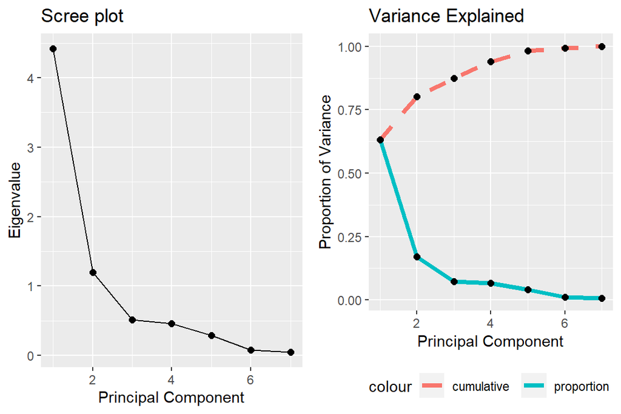

```r
# Scree plot
Scree = ggplot(results,aes(x=c(1:7),y=eigenvalues,group=1))+
          geom_line()+
          geom_point(size=2)+
          labs(x='Principal Component',y='Eigenvalue')+
          ggtitle('Scree plot')

# Variance Explained plot
VarExp = ggplot(results,aes(x=c(1:7),group=1))+
          geom_line(aes(y=cumulative,col = 'cumulative'),linetype = 'dashed',lwd=1.5)+
          geom_line(aes(y=proportion,col = 'proportion'),lwd=1.5)+
          geom_point(aes(y=cumulative),size=2)+
          geom_point(aes(y=proportion),size=2)+
          labs(x='Principal Component',y='Proportion of Variance')+
          theme(legend.position='bottom')+
          ggtitle('Variance Explained')

ggarrange(Scree,VarExp,ncol=2,nrow=1)
```

```r
print("Correlation matrix for the dataset:")
cor(H)

print("First and Second principal components:")
pca$loadings[,1] = -1*pca$loadings[,1]
pca$loadings[,1:2]
# for convenience the loadings and scores of PC1 are multiplied by 1.
```

```
## [1] "Correlation matrix for the dataset:"
```

```
##               Hurdles    High.Jump       Shot     Run200    Longjump
## Hurdles    1.00000000 -0.811402536 -0.6252580  0.7737205 -0.90321261
## High.Jump -0.81140254  1.000000000  0.4307521 -0.4876637  0.78222009
## Shot      -0.62525804  0.430752096  1.0000000 -0.6496633  0.73889970
## Run200     0.77372054 -0.487663685 -0.6496633  1.0000000 -0.80345072
## Longjump  -0.90321261  0.782220090  0.7388997 -0.8034507  1.00000000
## Javelin    0.01354169  0.002874155  0.2987463 -0.2883661  0.06720598
## Run800     0.76911298 -0.589774958 -0.4179724  0.6015774 -0.69698069
##                Javelin     Run800
## Hurdles    0.013541686  0.7691130
## High.Jump  0.002874155 -0.5897750
## Shot       0.298746305 -0.4179724
## Run200    -0.288366078  0.6015774
## Longjump   0.067205976 -0.6969807
## Javelin    1.000000000  0.0158585
## Run800     0.015858499  1.0000000
```

```
## [1] "First and Second principal components:"
```

```
##                Comp.1      Comp.2
## Hurdles   -0.45332304  0.16819470
## High.Jump  0.38060166 -0.23754879
## Shot       0.35927102  0.32976576
## Run200    -0.40521653 -0.22341799
## Longjump   0.45804584 -0.04574957
## Javelin    0.07139478  0.84120597
## Run800    -0.37611339  0.21656305
```

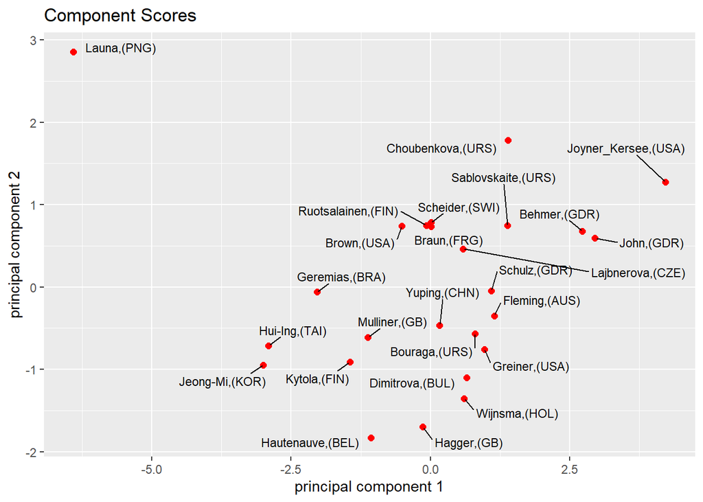

```r
# scores plot for PC1 and PC2
scores = data.frame(pca$scores)
ggplot(scores,aes(x = -1*scores[,1],y = scores[,2]))+
  geom_point(col = 'red',size = 2)+
  geom_text_repel(aes(label = competitors),box.padding = 0.5,size=3)+
  labs(x = 'principal component 1',y = 'principal component 2')+
  ggtitle('Component Scores')
```

We should retain 2 principal components since only 2 eigenvalues are > 1 and the scree plot flattens out from eigenvalue no. 3. We want to keep those that are above the flat part of the plot.If we consider the first principal component it turns out that javelin has a very low coefficient. For the remaining we see positive coefficients for highjump, shot and longjump, and negative for the running variables hurdles, run200m and run800m. This is in good accordance with the correlations. E.g. we have that shot is relative strongly correlated with highjump and longjump, and negatively correlated with the running variables.

The second principal component has a very strong weight on javelin.

From the score plot we see that the gold medal winner (athlete no. 1, Joyner Kersee) has the largest value of principal component no 1 and the third largest score of component no. 2, corresponding to that she is a versatile athlete.

**3.Think about how you should modify the data set such that you can use the variance-covariance matrix instead of the correlation matrix?**

The units involved in the different variables are time and distance. Combining those in an analysis would require that they are standardized with their individual standard deviations. And the analysis on those standardized variables will be identical to analyzing the correlation matrix!